# Spatial Autocorrelation & Spatial Econometrics

Mariam Walaa

```r
# Library to load shape file into a spatial object using readOGR.
library(rgdal)

# Library to automatically compute Moran's I using correlog.
library(pgirmess)

# Library to:
# - Create contiguity neighbor lists (poly2nb)
# - Create neighbor weight lists (nb2listw)
# - Compute the Moran's I statistic (moran.test)
# - Estimate spatial lag models (lagsarlm)
# - Perform Lagrange Multiplier tests (lm.LMtests)
library(spdep)

# Library to estimate spatial error models.
library(spatialreg)

# Library for data classification.
library(classInt)

# Library for color schemes.
library(RColorBrewer)
```

# Part 1: Spatial Autocorrelation

This part will use the U.S. Census 2010 data on the Hispanic population in Salt Lake County, estimated at the census tract level of aggregation. The shape file is projected into U.T.M. Zone 12 coordinates (i.e. coordinates measured in meters). The shape file of census tracts will be loaded into a spatial object below.

### Loading and Plotting

The shape file of census tracts in Salt Lake Country has 32 fields and 211 features. A choropleth map of the HIS_PCT variable is created below using the quantile classification method, a sequential color scheme, and 5 classes. The HIS_PCT variable is the proportion of Hispanic people in each census tract. The quantile classification method bins the variable of interest into groups of equal size and is chosen for this map as it seems to visually display more variation than Jenks natural breaks or standard deviation. The sequential color scheme is chosen since it makes sense to use a lighter value to represent lower proportions of Hispanic people within a census tract and a higher value to represent higher proportions of Hispanic people within a census tract. The number of classes chosen is 5.

```r
SLCCT <- readOGR(dsn = "../data/tutorial_saltlake", layer = "SLC_CT2010")
```

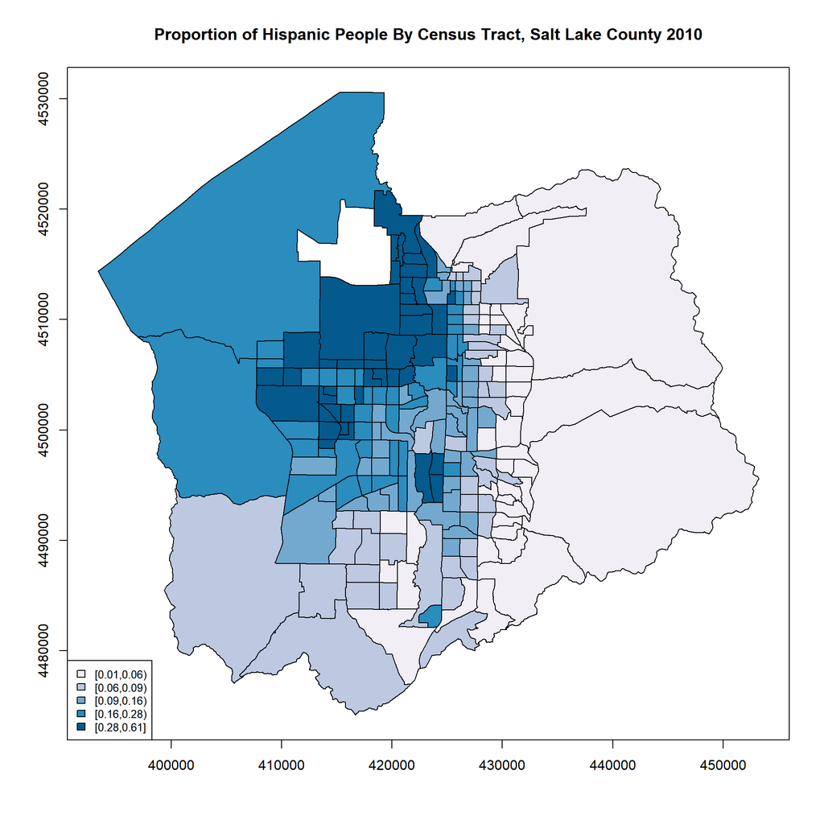

```r
# Define the number of classes.
nclasses <- 5

# Define the classification method. Available methods include: "equal", "sd", "quantile", "kmeans", "jenks"
class <- classIntervals(var = SLCCT$HIS_PCT, n = nclasses, style = "quantile", dataPrecision = 2)

# Set color palette.
colcode <- findColours(clI = class, pal = brewer.pal(nclasses, "PuBu"), digits = 3)

# Plot the map.
plot(SLCCT, col = colcode, border = "black", axes = T)

# Add a title.
title(main = "Proportion of Hispanic People By Census Tract, Salt Lake County 2010")

# Add a legend.
legend("bottomleft", legend = names(attr(colcode, "table")), fill = attr(colcode, "palette"), cex = 0.8)
```

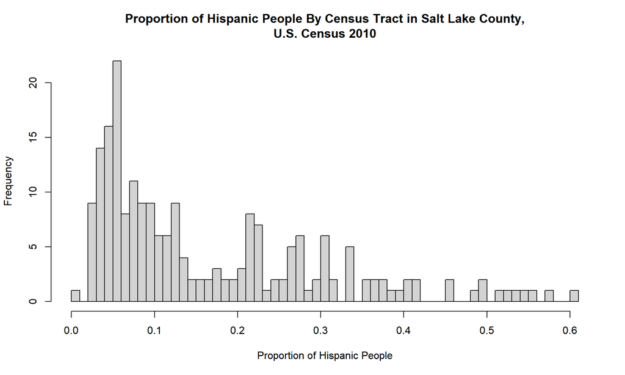

```r
hist(x = SLCCT$HIS_PCT, breaks = 60, xlab = "Proportion of Hispanic People",
     main = paste("Proportion of Hispanic People By Census Tract in Salt Lake County,",
                "U.S. Census 2010", sep = "\n"))
```

```r
summary(SLCCT$HIS_PCT)
```

```
##     Min.  1st Qu.   Median     Mean  3rd Qu.     Max.
## 0.007463 0.055368 0.110574 0.165272 0.249988 0.604172
```

### Working with Neighbor Lists

The relationships between the census tracts can be explored in order to measure spatial autocorrelation using neighbor graphs and weights. This is a two-step process that consists of first choosing the neighbor criterion that needs to be satisfied and then choosing the method to assign weights to the identified neighbor links. For the first step, the spatial object storing the census tract geographic data has been used in the process of creating graphs of two different neighbor criterion types (Rook and Queen).The Queen neighbors list is expected to contain more links since the queen condition can be met by a single shared boundary point, while the rook condition can only be met by more than one shared point.

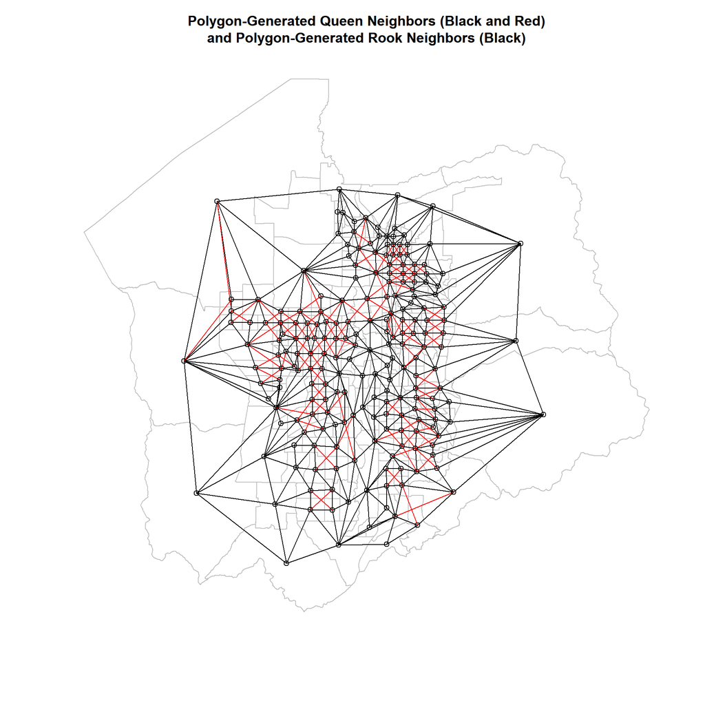

```r
# Retrieve coordinates from spatial object.
coords <- coordinates(SLCCT)

# Create a rook contiguity neighbor list.
SLCnb_rook <- poly2nb(pl = SLCCT, queen = FALSE)

# Create a queen contiguity neighbor list.
SLCnb_queen <- poly2nb(pl = SLCCT)

# Find differences between the two contiguity neighbor lists.
diff_nb <- diffnb(x = SLCnb_queen, y = SLCnb_rook)

# Plot the census tract boundaries.
plot(x = SLCCT, border = "grey")

# Plot the queen neighbors.
plot(x = SLCnb_queen, coords, add = TRUE, col = "black")

# Plot the differences between the rook and queens neighbor lists.
plot(x = diff_nb, coords, add = TRUE, col = "red")

# Add a title.
title(main = paste("Polygon-Generated Queen Neighbors (Black and Red)",
                 "and Polygon-Generated Rook Neighbors (Black)", sep = "\n"))
```

```r
summary(card(SLCnb_rook))
```

```
##    Min. 1st Qu.  Median    Mean 3rd Qu.    Max.
##   3.000   4.000   5.000   5.185   6.000  13.000
```

```r
summary(card(SLCnb_queen))
```

```
##    Min. 1st Qu.  Median    Mean 3rd Qu.    Max.
##   3.000   5.000   6.000   6.474   7.000  14.000
```

The summary statistics of the Rook and Queen neighbors shows that none of the methods have a normal distribution, and the Queen neighbor list contains more links as expected. This has been achieved using the helper function card which provides the cardinality of the neighbor set. The neighbor map shows that there are many more neighbor links through the queen condition than the rook condition. This is especially the case in areas where there are smaller census tracts (north east and north west of the center of the map). This can be confirmed by the number of nonzero links given by summary(SLCnb_queen), which show there are about 300 more links using the queen condition.

### Creating Weight Matrices from Neighbor Lists

For the second step, matrices of weights have been created for the neighbor lists. These weight matrices are contained in a listw object which is made up of the following three attributes:

- The style of the weight matrix, which can be ‘B’ (binary), ‘W’ (row-normalized), etc.
- The input neighbors list, which is a list of values representing the number of neighbors for each region
- The weights for each neighbor link based on the chosen style, which is a list of lists where each sublist contains weights for that region (if using ‘W’ style, each region will have different weights based on the number of neighbors the region has)

```r
# Create binary weight matrices
SLCnb_rook_B <- nb2listw(SLCnb_rook, style = "B")
SLCnb_queen_B <- nb2listw(SLCnb_queen, style = "B")

# Create normalized weight matrices
SLCnb_rook_W <- nb2listw(SLCnb_rook, style = "W")
SLCnb_queen_W <- nb2listw(SLCnb_queen, style = "W")

SLCnb_queen_B$weights[1]
```

```
## [[1]]
## [1] 1 1 1 1 1 1 1 1 1
```

```r
SLCnb_queen_W$weights[1]
```

```
## [[1]]
## [1] 0.1111111 0.1111111 0.1111111 0.1111111 0.1111111 0.1111111 0.1111111
## [8] 0.1111111 0.1111111
```

```r
SLCnb_rook_B$weights[1]
```

```
## [[1]]
## [1] 1 1 1 1 1 1
```

```r
SLCnb_rook_W$weights[1]
```

```
## [[1]]
## [1] 0.1666667 0.1666667 0.1666667 0.1666667 0.1666667 0.1666667
```

The weights object is a list of lists where each sub-list contains all the weights for a census tract. For example, the first observation has 9 neighbor weights using the queen condition and 6 neighbor weights using the rook condition. The weights for each neighbor of a single observation or census tract are represented as 1s using the binary weighting scheme and as decimals using the row-normalized weighting scheme. The values in the row-normalized matrix are based on the number of neighbors for that observation.

### Global Moran’s I

```r
# Compute Global Moran's I for each weight matrix
print(moran.test(SLCCT$HIS_PCT, listw = SLCnb_rook_B))
```

```
##
##  Moran I test under randomisation
##
## data:  SLCCT$HIS_PCT
## weights: SLCnb_rook_B
##
## Moran I statistic standard deviate = 18.791, p-value < 2.2e-16
## alternative hypothesis: greater
## sample estimates:
## Moran I statistic       Expectation          Variance
##       0.785957000      -0.004761905       0.001770772
```

```r
print(moran.test(SLCCT$HIS_PCT, listw = SLCnb_rook_W))
```

```
##
##  Moran I test under randomisation
##
## data:  SLCCT$HIS_PCT
## weights: SLCnb_rook_W
##
## Moran I statistic standard deviate = 18.812, p-value < 2.2e-16
## alternative hypothesis: greater
## sample estimates:
## Moran I statistic       Expectation          Variance
##       0.800642013      -0.004761905       0.001833075
```

```r
print(moran.test(SLCCT$HIS_PCT, listw = SLCnb_queen_B))
```

```
##
##  Moran I test under randomisation
##
## data:  SLCCT$HIS_PCT
## weights: SLCnb_queen_B
##
## Moran I statistic standard deviate = 19.76, p-value < 2.2e-16
## alternative hypothesis: greater
## sample estimates:
## Moran I statistic       Expectation          Variance
##       0.736971498      -0.004761905       0.001409101
```

```r
print(moran.test(SLCCT$HIS_PCT, listw = SLCnb_queen_W))
```

```
##
##  Moran I test under randomisation
##
## data:  SLCCT$HIS_PCT
## weights: SLCnb_queen_W
##
## Moran I statistic standard deviate = 20.502, p-value < 2.2e-16
## alternative hypothesis: greater
## sample estimates:
## Moran I statistic       Expectation          Variance
##       0.778577913      -0.004761905       0.001459817
```

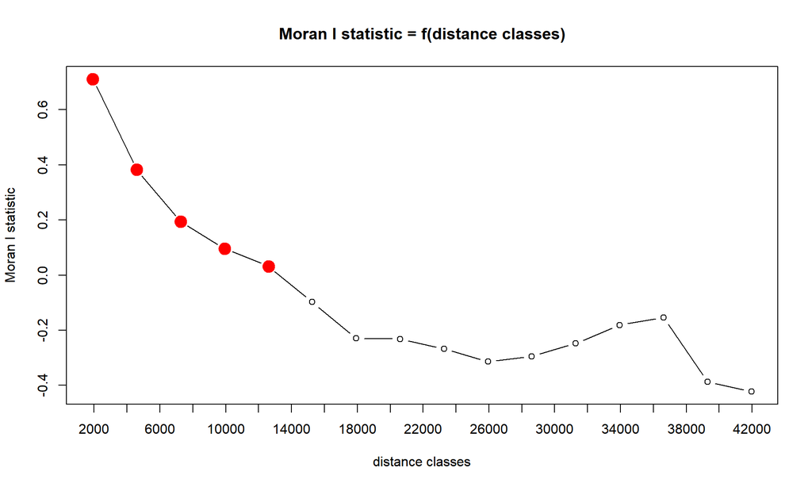

```r
# Compute and plot Moran's I for different distances
plot(correlog(coords, SLCCT$HIS_PCT, method = "Moran"))
```

This is a plot of global Moran’s I values for the percentage of Hispanic people in each census tract using different distances. The plot highlights the distances for which the Moran’s I statistic is statistically significant. The plot shows that a distance class around 2000 provides the largest Moran’s I statistic of above 0.6, while larger distance classes result in less autocorrelation.

# Part 2: Spatial Econometrics

This part will use a crime data set pertaining to planning neighborhoods in Columbus, Ohio (1980). The dependent variable of interest is CRIME, the number of residential burglaries and vehicle thefts per 1000 households. The two independent variables are HOVAL, the median housing value in $1000’s, and INC, the median household income in $1000’s.

### Load and Describe the Data set

```r
columbus <- readOGR(dsn = "../data/tutorial_columbus", layer = "columbus")
```

The shape file of census tracts in Columbus, Ohio has 20 fields and 49 features.

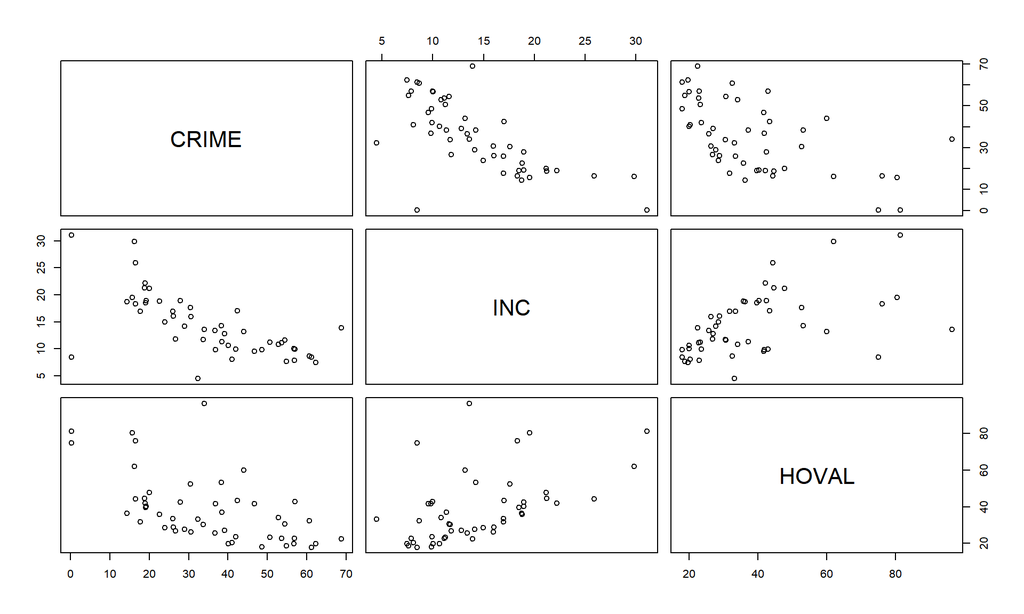

```r
# Convert to data frame for univariate and bivariate plots below
crime_df <- as.data.frame(cbind(columbus$CRIME,columbus$INC, columbus$HOVAL))
colnames(crime_df) <- c( 'CRIME', 'INC', 'HOVAL')

# Plot pairwise correlations
plot(crime_df)
```

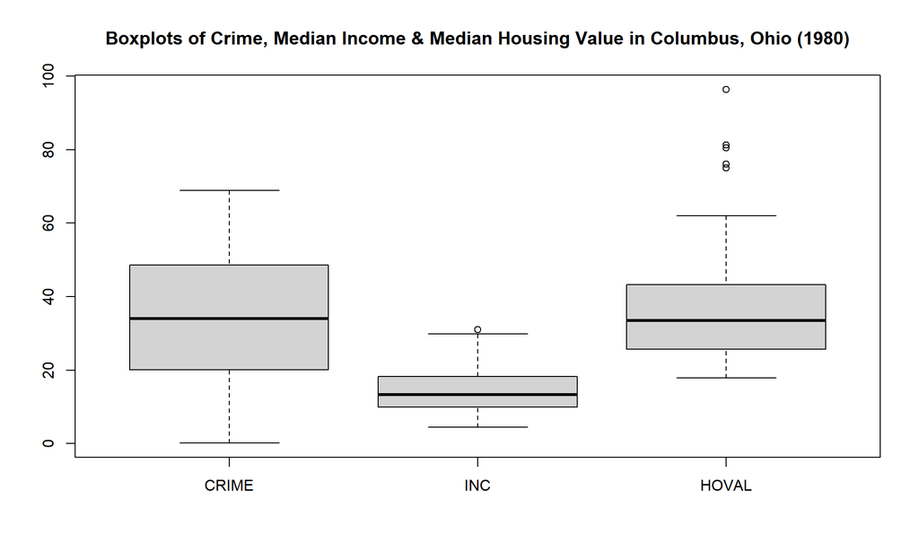

```r
# Plot quantiles for each variable
boxplot(crime_df, main = "Boxplots of Crime, Median Income & Median Housing Value in Columbus, Ohio (1980)")
```

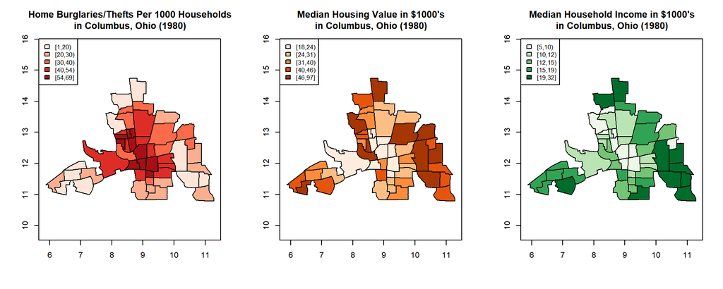

```r
par(mfrow = c(1,3))

# Define the number of classes.
nclasses <- 5

# Define the classification method. Available methods include: "equal", "sd", "quantile", "kmeans", "jenks"
class <- classIntervals(var = columbus$CRIME, n = nclasses, style = "quantile", dataPrecision = 0)

# Set color palette.
colcode <- findColours(clI = class, pal = brewer.pal(nclasses, "Reds"), digits = 3)

# Plot the map.
plot(columbus, col = colcode, pch = 19, axes = T, cex = 1.5)

# Add a title.
title(main = paste("Home Burglaries/Thefts Per 1000 Households",
                 "in Columbus, Ohio (1980)", sep = "\n"))

# Add a legend.
legend("topleft", legend = names(attr(colcode, "table")), fill = attr(colcode, "palette"), cex = 0.8)

# Plot a second map for median housing value
class <- classIntervals(var = columbus$HOVAL, n = nclasses, style = "quantile", dataPrecision = 0)
colcode <- findColours(clI = class, pal = brewer.pal(nclasses, "Oranges"), digits = 3)
plot(columbus, col = colcode, pch = 19, axes = T, cex = 1.5)
title(main = paste("Median Housing Value in $1000's", "in Columbus, Ohio (1980)", sep = "\n"))
legend("topleft", legend = names(attr(colcode, "table")), fill = attr(colcode, "palette"), cex = 0.8)

# Plot a third map for median household income
class <- classIntervals(var = columbus$INC, n = nclasses, style = "quantile", dataPrecision = 0)
colcode <- findColours(clI = class, pal = brewer.pal(nclasses, "Greens"), digits = 3)
plot(columbus, col = colcode, pch = 19, axes = T, cex = 1.5)
title(main = paste("Median Household Income in $1000's", "in Columbus, Ohio (1980)", sep = "\n"))
legend("topleft", legend = names(attr(colcode, "table")), fill = attr(colcode, "palette"), cex = 0.8)
```

The plot of pairwise correlations shows that crime is negatively correlated with both median household income and median housing value, while median household income and median housing value are positively correlated. The boxplots show that the distribution of crime levels is normal while median household income is slightly right-skewed with an outlier and median housing value is also right-skewed but has more outliers.

- In the crimes map, there are some clusters of census tracts belonging to the same class interval. This is especially the case at the centre of the map for the largest class interval, and also the case to the south for the small class interval, and also to the middle class interval. This indicates that the proportion of crime in a census tract may determine the proportion of crime in nearby census tracts.
- In the median housing value map, there are few clusters of census tracts belonging to the same class interval. There are two clusters east of the map where surrounding census tracts belong to the same class, but there is dispersion for the remainder of the map. This indicates that the proportion of median housing value in a census tract may not determine well what the proportion of neighboring census tracts is.
- In the median household income map, there are some clusters of census tracts belonging to the same class interval. This is the case for multiple areas in the map, especially south east and south west of the map for the larger class intervals. This indicates that the median household income interval a census tract belongs to may determine the median household income class interval of nearby census tracts.

### Perform Basic Spatial Statistics

```r
# Create a queen contiguity neighbor list.
columbusnb_queen <- poly2nb(pl = columbus)

# Create a row-normalized weight matrix.
columbusnb_queen_W <- nb2listw(columbusnb_queen, style = "W")

# Compute Global Moran's I
moran_queen_crime <- moran.test(x = columbus$CRIME, listw = columbusnb_queen_W)
moran_queen_hoval <- moran.test(x = columbus$HOVAL, listw = columbusnb_queen_W)
moran_queen_inc <- moran.test(x = columbus$INC, listw = columbusnb_queen_W)

summary(columbusnb_queen_W)
```

```
## Characteristics of weights list object:
## Neighbour list object:
## Number of regions: 49
## Number of nonzero links: 236
## Percentage nonzero weights: 9.829238
## Average number of links: 4.816327
## Link number distribution:
##
##  2  3  4  5  6  7  8  9 10
##  5  9 12  5  9  3  4  1  1
## 5 least connected regions:
## 0 5 41 45 46 with 2 links
## 1 most connected region:
## 19 with 10 links
##
## Weights style: W
## Weights constants summary:
##    n   nn S0       S1       S2
## W 49 2401 49 22.75119 203.7091
```

```r
print(moran_queen_crime)
```

```
##
##  Moran I test under randomisation
##
## data:  columbus$CRIME
## weights: columbusnb_queen_W
##
## Moran I statistic standard deviate = 5.5894, p-value = 1.139e-08
## alternative hypothesis: greater
## sample estimates:
## Moran I statistic       Expectation          Variance
##       0.500188557      -0.020833333       0.008689289
```

```r
print(moran_queen_hoval)
```

```
##
##  Moran I test under randomisation
##
## data:  columbus$HOVAL
## weights: columbusnb_queen_W
##
## Moran I statistic standard deviate = 2.2071, p-value = 0.01365
## alternative hypothesis: greater
## sample estimates:
## Moran I statistic       Expectation          Variance
##       0.180093114      -0.020833333       0.008287783
```

```r
print(moran_queen_inc)
```

```
##
##  Moran I test under randomisation
##
## data:  columbus$INC
## weights: columbusnb_queen_W
##
## Moran I statistic standard deviate = 4.7645, p-value = 9.467e-07
## alternative hypothesis: greater
## sample estimates:
## Moran I statistic       Expectation          Variance
##       0.415628778      -0.020833333       0.008391926
```

Here are the summary statistics for the Queen neighbor graph:

- The average number of neighbor links for each zone is 4.816327.
- The minimum number of connections made in the neighbor list (i.e., minimum neighbors) is 2.
- The maximum number of connections made in the neighbor list (i.e., maximum neighbors) is 10.
- The Global Moran’s I statistic for CRIME is 0.500188557 and it is strongly statistically significant.
- The Global Moran’s I statistic for HOVAL is 0.180093114 and it is statistically significant.
- The Global Moran’s I statistic for INC is 0.415628778 and it is strongly statistically significant.
- The CRIME variable is most spatially autocorrelated of all three variables with around 0.5 Moran’s I autocorrelation, followed by INC with around 0.42 Moran’s I autocorrelation. HOVAL has a lower autocorrelation of around 0.18. These autocorrelation values seem reasonable given the map patterns seen above.

### Create an OLS Model for Crime

```r
# Estimate an OLS model without lag
ols_model <- lm(columbus$CRIME ~ columbus$INC + columbus$HOVAL)
summary(ols_model)
```

```
##
## Call:
## lm(formula = columbus$CRIME ~ columbus$INC + columbus$HOVAL)
##
## Residuals:
##     Min      1Q  Median      3Q     Max
## -34.418  -6.388  -1.580   9.052  28.649
##
## Coefficients:
##                Estimate Std. Error t value Pr(>|t|)
## (Intercept)     68.6190     4.7355  14.490  < 2e-16 ***
## columbus$INC    -1.5973     0.3341  -4.780 1.83e-05 ***
## columbus$HOVAL  -0.2739     0.1032  -2.654   0.0109 *
## ---
## Signif. codes:  0 '***' 0.001 '**' 0.01 '*' 0.05 '.' 0.1 ' ' 1
##
## Residual standard error: 11.43 on 46 degrees of freedom
## Multiple R-squared:  0.5524, Adjusted R-squared:  0.5329
## F-statistic: 28.39 on 2 and 46 DF,  p-value: 9.341e-09
```

```r
# Compute Moran's I for the OLS model's residuals
moran.test(resid(ols_model), columbusnb_queen_W)
```

```
##
##  Moran I test under randomisation
##
## data:  resid(ols_model)
## weights: columbusnb_queen_W
##
## Moran I statistic standard deviate = 2.6521, p-value = 0.003999
## alternative hypothesis: greater
## sample estimates:
## Moran I statistic       Expectation          Variance
##       0.222109407      -0.020833333       0.008391173
```

Here is an interpretation of the OLS model output:

- Here is the regression formula: CRIME = -1.5973*INC -0.2739*HOVAL + 68.6190
  - For an increase of 1 unit in income, we expect to find a decrease of 1.5973 in crime.
  - For an increase of 1 unit in housing value, we expect to find a decrease of 0.2739 in crime.
- The goodness of fit (Adjusted R^2) is 0.5329 which means that around 53% of the data is explained well by this model.
- The Moran’s I measure is computed for the OLS model’s residuals in order to see if the OLS model’s residuals violate the regression assumption of being independent. Based on the Moran’s I statistic, the residuals of the model are have a statistically significant autocorrelation of 0.222109407. This means it is possible that there is a spatial dependence between observations, so the observations may not be independently distributed.

Based on all of these results, the model may not be valid as a statistically significant Moran’s I indicates that there may be spatial dependence which will lead to biased coefficients and underestimated standard error. Therefore, possible options for creating a valid model given these results are estimating a spatial lag and spatial error model. The difference between a spatial lag model and a spatial error model is that the spatial lag model assumes that the dependent variable has spatial dependence while the spatial error model assumes that there may be some unknown dependence in the error.

### Create a Spatially Lagged Dependent Model

This part will create a spatially lagged dependent model. A spatial lag will be created and passed to the OLS model. This is not an appropriate method of estimation, but it will be used to compare the differences between the OLS with lag and maximum likelihood estimation with lag.

```r
# Create a new variable that contains the spatially lagged levels of crime for each zone
wy <- lag(columbusnb_queen_W, columbus$CRIME)

# Specify a new OLS model for crime as a function of the lagged crime levels variable
ols_lag_model <- lm(columbus$CRIME ~ wy + columbus$INC + columbus$HOVAL)
summary(ols_lag_model)
```

```
##
## Call:
## lm(formula = columbus$CRIME ~ wy + columbus$INC + columbus$HOVAL)
##
## Residuals:
##     Min      1Q  Median      3Q     Max
## -38.610  -6.198   0.188   6.810  21.718
##
## Coefficients:
##                Estimate Std. Error t value Pr(>|t|)
## (Intercept)    38.78334    9.32251   4.160 0.000141 ***
## wy              0.54876    0.15288   3.589 0.000815 ***
## columbus$INC   -0.88617    0.35773  -2.477 0.017064 *
## columbus$HOVAL -0.26408    0.09204  -2.869 0.006245 **
## ---
## Signif. codes:  0 '***' 0.001 '**' 0.01 '*' 0.05 '.' 0.1 ' ' 1
##
## Residual standard error: 10.19 on 45 degrees of freedom
## Multiple R-squared:  0.652,  Adjusted R-squared:  0.6288
## F-statistic: 28.11 on 3 and 45 DF,  p-value: 2.149e-10
```

```r
# Compute Moran's I for the OLS lag model's residuals
moran.test(resid(ols_lag_model), columbusnb_queen_W)
```

```
##
##  Moran I test under randomisation
##
## data:  resid(ols_lag_model)
## weights: columbusnb_queen_W
##
## Moran I statistic standard deviate = 0.027316, p-value = 0.4891
## alternative hypothesis: greater
## sample estimates:
## Moran I statistic       Expectation          Variance
##       -0.01840567       -0.02083333        0.00789821
```

```r
# Estimate a spatial lag model with the same predictors as above.
spatial_lag_model <- lagsarlm(columbus$CRIME ~ wy + columbus$INC + columbus$HOVAL, listw = columbusnb_queen_W)
summary(spatial_lag_model)
```

```
##
## Call:lagsarlm(formula = columbus$CRIME ~ wy + columbus$INC + columbus$HOVAL,
##     listw = columbusnb_queen_W)
##
## Residuals:
##       Min        1Q    Median        3Q       Max
## -38.61039  -6.19766   0.18781   6.81004  21.71848
##
## Type: lag
## Coefficients: (asymptotic standard errors)
##                 Estimate Std. Error z value  Pr(>|z|)
## (Intercept)    38.783341   9.106084  4.2591 2.053e-05
## wy              0.548763   0.209620  2.6179  0.008847
## columbus$INC   -0.886175   0.343037 -2.5833  0.009785
## columbus$HOVAL -0.264084   0.088469 -2.9851  0.002835
##
## Rho: 2.3465e-08, LR test value: 5.6843e-14, p-value: 1
## Asymptotic standard error: 0.18716
##     z-value: 1.2537e-07, p-value: 1
## Wald statistic: 1.5718e-14, p-value: 1
##
## Log likelihood: -181.2085 for lag model
## ML residual variance (sigma squared): 95.43, (sigma: 9.7688)
## Number of observations: 49
## Number of parameters estimated: 6
## AIC: 374.42, (AIC for lm: 372.42)
## LM test for residual autocorrelation
## test value: 0.17606, p-value: 0.67478
```

```r
# Compute Moran's I for the spatial lag models' residuals
moran.test(resid(spatial_lag_model), columbusnb_queen_W)
```

```
##
##  Moran I test under randomisation
##
## data:  resid(spatial_lag_model)
## weights: columbusnb_queen_W
##
## Moran I statistic standard deviate = 0.027316, p-value = 0.4891
## alternative hypothesis: greater
## sample estimates:
## Moran I statistic       Expectation          Variance
##       -0.01840567       -0.02083333        0.00789821
```

|  | OLS No Lag |  | OLS With Lag |  | Maximum Likelihood with Lag |  |
| --- | --- | --- | --- | --- | --- | --- |
|  | Coefficient | p-value | Coefficient | p-value | Coefficient | p-value |
| Constant | 68.619 | < 0.0000000000000002 | 38.78334 | 0.000141 | 38.783341 | 0.00002053 |
| INC | -1.5973 | 0.0000183 | -0.88617 | 0.017064 | -0.886175 | 0.009785 |
| HOVAL | -0.2739 | 0.0109 | -0.26408 | 0.006245 | -0.264084 | 0.002835 |
| WCRIME | NA | NA | 0.54876 | 0.000815 | 0.548763 | 0.008847 |
| Adj-R2 | 0.5329 | NA | 0.6288 | NA | NA | NA |
| Moran’s I for residuals | 0.222109407 | 0.003999 | -0.01840567 | 0.4891 | -0.01840567 | 0.4891 |

Here is a description of the differences between the statistics of the three models above:

- The coefficients of the median housing value (HOVAL) and the median household income (INC) are negative in all three models. These coefficients are similar for the models with a spatial lag (OLS and Maximum Likelihood). The coefficients of the OLS without a lag are lower. All three models have coefficient estimates that are statistically significant.
- Both OLS models (with a lag and without a lag) have an adjusted R^2 larger than 50%. The OLS model with a lag has a larger adjusted R^2.
- The spatial autocorrelation of the residuals is around 0.22 for the OLS with no lag and around -0.02 for the two models with a lag (both OLS and Maximum Likelihood).
- The OLS model with no lag differs from the OLS model with a lag in that the coefficients for the model with no lag are much smaller.
- The OLS model with a lag differs from the Maximum Likelihood model with a lag in that the coefficient estimates for the Maximum Likelihood model are more statistically significant overall, but the coefficient estimates themselves for both models are about the same.

An OLS model with a spatial lag is not an appropriate model. In this case, the spatial lag model has coefficient estimates that are more statistically significant than the coefficient estimates for the OLS with a lag.

### Create a Spatially Lagged Error Model for Crime

```r
# Estimate a spatial error model
error_model <- errorsarlm(columbus$CRIME ~ columbus$INC + columbus$HOVAL, listw=columbusnb_queen_W)
summary(error_model)
```

```
##
## Call:errorsarlm(formula = columbus$CRIME ~ columbus$INC + columbus$HOVAL,
##     listw = columbusnb_queen_W)
##
## Residuals:
##       Min        1Q    Median        3Q       Max
## -34.65998  -6.16943  -0.70623   7.75392  23.43878
##
## Type: error
## Coefficients: (asymptotic standard errors)
##                 Estimate Std. Error z value  Pr(>|z|)
## (Intercept)    60.279469   5.365594 11.2344 < 2.2e-16
## columbus$INC   -0.957305   0.334231 -2.8642 0.0041806
## columbus$HOVAL -0.304559   0.092047 -3.3087 0.0009372
##
## Lambda: 0.54675, LR test value: 7.2556, p-value: 0.0070679
## Asymptotic standard error: 0.13805
##     z-value: 3.9605, p-value: 7.4786e-05
## Wald statistic: 15.686, p-value: 7.4786e-05
##
## Log likelihood: -183.7494 for error model
## ML residual variance (sigma squared): 97.674, (sigma: 9.883)
## Number of observations: 49
## Number of parameters estimated: 5
## AIC: 377.5, (AIC for lm: 382.75)
```

```r
# Compute Moran's I for the residuals of the error model
moran.test(resid(error_model), columbusnb_queen_W)
```

```
##
##  Moran I test under randomisation
##
## data:  resid(error_model)
## weights: columbusnb_queen_W
##
## Moran I statistic standard deviate = 0.36435, p-value = 0.3578
## alternative hypothesis: greater
## sample estimates:
## Moran I statistic       Expectation          Variance
##       0.012210261      -0.020833333       0.008224812
```

### Choose Between Several Valid Models

```r
# Perform Lagrange Multiplier diagnostics
lm_tests <- lm.LMtests(ols_model, listw = columbusnb_queen_W, test = "all")

# Summarize the outputs into a table
lm_results <- t(sapply(lm_tests, function(test) c(test$statistic, test$parameter, test$p.value)))
colnames(lm_results) <- c("statistic", "df", "p-value")

printCoefmat(lm_results)
```

```
##        statistic       df p-value
## LMerr   5.206214 1.000000  0.0225
## LMlag   8.897999 1.000000  0.0029
## RLMerr  0.043906 1.000000  0.8340
## RLMlag  3.735691 1.000000  0.0533
## SARMA   8.941905 2.000000  0.0114
```